# C03 — Portret próby: czas wyszukiwania, skuteczność i zróżnicowanie

Zarządzanie informacją — ćwiczenie i zadanie Z03 — 2026/27

ID: [UZUPELNIJ_ID]

2026/27

# Początek pracy na ćwiczeniu C03

Otwórz swój projekt kursu w Posit Cloud albo RStudio na własnym komputerze; pakiet kursu `badaniaZI` jest w nim zainstalowany. Dwa polecenia z następnego bloku wpisujesz w konsoli RStudio, czyli w dolnym panelu ze znakiem `>`; w miejsce `TWOJE_ID` wpisz swoje ID, a w miejsce `Imię Nazwisko` — swoje imię i nazwisko. Dokument PDF zawiera dwa polecenia jako tekst instrukcji.

```r
library(badaniaZI)
rozpocznij_zajecia("C03", id_studenta = "TWOJE_ID", student = "Imię Nazwisko")
```

Sprawdź w komunikacie ID oraz imię i nazwisko. Przy pierwszym starcie funkcja tworzy folder `moje-badania` i zapisuje w nim oba dane; pliki pracy zachowują je także po zamknięciu projektu, a imię i nazwisko trafiają do nazwy oddawanego pliku.

Funkcja `rozpocznij_zajecia()` otwiera własny plik `zadanie.Rmd`, zapamiętuje katalog pracy i kopiuje do folderu `moje-badania/materialy` wersję HTML i PDF ćwiczenia oraz rubrykę zadania. Pracuj w otwartym pliku `zadanie.Rmd` do końca zajęć. Najpierw uruchom blok `przygotowanie`, a potem kolejne części LEARN i CHALLENGE. Przy problemie poproś prowadzącego o pomoc; plik pracy i własne ID pozostają bez zmian.

Pierwszy chunk, `przygotowanie`, wczytuje gotowy skrypt `analiza.R`. Skrypt tworzy zbiór S02 po trzech regułach ćwiczenia C02 (usunięcie identycznych duplikatów, kod 99 w pozycjach ankiety jako brak, czas spoza 0–120 minut jako brak), dwie małe serie A i B po pięć czasów, tabelę `repozytorium` dwunastu osób do części CHALLENGE oraz funkcje wyświetlające tabele i wykresy. Wszystkie czasy z zakresu 0–120 minut, także długie, pozostają w danych. Skrypt działa bez zmian.

# Czy katalog działa sprawnie

Po przygotowaniu danych zespół biblioteki pyta: „Ile trwa znalezienie dokumentu?”. Pytanie ma cztery znaczenia: przeciętny nakład czasu, czas środkowej osoby, czas, w którym kończy zadanie zdecydowana większość osób, i czas udanych prób. Wybór miary zaczyna się od decyzji, której ma służyć odpowiedź.

Bibliotekarz planujący dyżur pyta o łączne obciążenie długimi próbami, projektant interfejsu — o doświadczenie środkowej części użytkowników, a osoba odpowiedzialna za dostępność — o osoby, które potrzebują najwięcej czasu. Trzy perspektywy wymagają trzech miar: średniej, mediany i wysokiego percentyla.

Druga część pytania brzmi: „Czy szybkie zakończenie oznacza powodzenie?”. Osoba może szybko zrezygnować albo wybrać niewłaściwy dokument, więc portret usługi łączy czas z poprawnością. Ćwiczenie zestawia czas z poprawnością jako dwa wskaźniki wykonania zadania.

Dane S02 są syntetyczne. Małe demonstracje używają dodatkowych serii liczb, oddzielonych od S02, a CHALLENGE dotyczy osobnego scenariusza repozytorium. Projekt indywidualny rozpoczyna się na ćwiczeniu C09 (Warsztat projektu); na C03 ćwiczysz sposób odczytu i pisania.

## Przebieg spotkania

Przeznacz około 5 minut na odtworzenie pracy, 30 minut na pięć bloków LEARN, 50 minut na pięć zadań CHALLENGE i 5 minut na zapis oraz oddanie. W LEARN uruchamiasz gotowy kod i porównujesz wynik z podaną interpretacją. W CHALLENGE piszesz własne krótkie akapity pod wynikami, poza blokiem R. Gdy odczyt wyniku sprawia trudność, pytasz prowadzącego. Rozwinięcia po części obowiązkowej służą powtórce i pozostają poza oceną.

Wynikiem C03 jest opis próby. Wniosek o populacji wymaga wnioskowania, które wprowadzają wykład W03 (Losowość, estymacja i dwa tory wnioskowania) i ćwiczenie C05 (Niepewność estymaty), a wniosek o przyczynie — projektu z losowym przydziałem.

Bloki LEARN kończą się **wzorcem zapisu** — przykładowym zdaniem według standardu APA (*Publication Manual of the American Psychological Association*, 7. wydanie, 2020): symbol statystyczny kursywą (*N*, *n*, *M*, *Mdn*, *SD*, *IQR*), jednostka przy liczbie, przecinek jako separator dziesiętny. Na ćwiczeniu C03 wzorce dotyczą opisu próby: położenia, rozrzutu, kwartyli, odsetków i porównania grup. Zadania CHALLENGE stosują wzorce do danych repozytorium.

# LEARN 1: pytanie, mianownik i środek rozkładu

Pytania zespołu i miary

| Pytanie zespołu | Miara | Jednostka lub mianownik |
| --- | --- | --- |
| Jaki był przeciętny nakład czasu? | Średnia | Minuty, ważne pomiary czasu |
| Gdzie leży środek uporządkowanych czasów? | Mediana | Minuty |
| Jak zróżnicowane były próby? | SD i IQR | Minuty |
| W jakim czasie kończy zadanie 90% prób? | Percentyl 90. | Minuty i poziom kwantyla |
| Jaka część osób znalazła dokument? | Proporcja powodzeń | Osoby ze znanym wynikiem |
| Jaka część znalazła go w określonym czasie? | Łączny warunek powodzenia i czasu | Osoby z oboma pomiarami |

Próg 10 minut jest umownym przykładem do czytania wyniku. W rzeczywistym projekcie próg wynika z celu usługi albo jest jawnie oznaczony jako eksploracyjny.

Estymandą opisu może być średni czas określonej populacji, mediana lub proporcja powodzeń. Ćwiczenie oblicza odpowiadające im statystyki w syntetycznej próbie; definicja wielkości obowiązuje także przy opisie bez uogólniania.

## Opis zaczyna się od N

Każda kolumna ma własną liczbę ważnych wartości: w S02 po przygotowaniu czas ma 142 ważne wartości, powodzenie 148, a indeks — tyle, ile osób spełnia regułę pięciu ważnych pozycji. Czas osoby bywa nieznany przy zapisanym powodzeniu.

Funkcja `opis_czasu_do_raportu()` zwraca tabelę „Miary czasu [min], liczebność i braki” z jedną miarą w wierszu: N = 142 ważnych czasów, 6 braków, średnia 10,13, mediana 8,25, SD 5,85, Q1 5,8, Q3 12,975, IQR 7,175 i P90 18,24 minuty. Najpierw odczytaj N i braki, potem wartości położenia i zróżnicowania.

```r
czas <- opis_czasu_do_raportu(dane$czas_wyszukiwania)
print(czas)
```

**Miary czasu [min], liczebność i braki**

| Miara | Wartość |
| --- | --- |
| N (ważne czasy) | 142,000 |
| Braki czasu | 6,000 |
| Średnia | 10,128 |
| Mediana | 8,250 |
| SD | 5,854 |
| Q1 | 5,800 |
| Q3 | 12,975 |
| IQR | 7,175 |
| P90 | 18,240 |

Wynik opisuje zarejestrowane czasy spełniające reguły przygotowania; sześć braków czasu pozostaje brakami. Gdy braki wiążą się z trudnością zadania, podsumowanie pomija część doświadczenia użytkowników, więc raport podaje ich liczbę.

`Q1` i `Q3` oznaczają kwartyle, `P90` — percentyl 90., `SD` — odchylenie standardowe, a `IQR` — rozstęp międzykwartylowy. Tabela podaje trzy miejsca po przecinku dla czytelności; czas zapisano z dokładnością do 0,1 minuty.

## Język wzorów opisowych

Symbole ćwiczenia C03

| Symbol | Jak czytać? | Znaczenie badawcze |
| --- | --- | --- |
| $x_i$ | czas i-tej osoby | Jedna ważna obserwacja |
| $x_{(r)}$ | r-ta wartość po uporządkowaniu | Pozycja w uporządkowanym zbiorze |
| $\bar{x}$ | średnia w próbie | Suma czasu na pomiar |
| $Me$ | mediana | Środek uporządkowanych wartości |
| $Q_1,Q_3$ | pierwszy i trzeci kwartyl | Granice środkowej połowy rozkładu |
| $s$ lub SD | odchylenie standardowe | Rozrzut względem średniej |
| $s^2$ | wariancja | Średni kwadrat odchylenia z korektą $n-1$ |
| $\hat{\pi}$ | oszacowana proporcja | Licznik podzielony przez właściwy mianownik |

Zapis „SD = 4” wymaga nazwy zmiennej i jednostki: „SD czasu wyniosło 4 minuty” opisuje typową skalę odchyleń czasów osób od średniej. Precyzję średniej opisuje błąd standardowy, a zakres wszystkich czasów — minimum i maksimum. Kilka małych przykładów wyjaśnia działanie gotowej funkcji przed odczytem pełnego zbioru.

## Średnia i mediana odpowiadają na dwa pytania

$$\bar{x}=\frac{x_1+\cdots+x_n}{n},\qquad
Me=
\begin{cases}
x_{((n+1)/2)}, & n \text{ nieparzyste},\\[2pt]
\tfrac12\left(x_{(n/2)}+x_{(n/2+1)}\right), & n \text{ parzyste}.
\end{cases}$$

W serii A czasy wynoszą 2, 4, 6, 8 i 10 minut: suma 30, średnia 6 minut, a mediana $x_{(3)}=6$ minut. Równość średniej i mediany w serii A wynika z symetrii serii. W serii B ostatni czas wynosi 30 minut: średnia rośnie do 10, a mediana pozostaje równa 6, bo zmiana ostatniej wartości przesuwa sumę, a środkowa obserwacja pozostaje ta sama. Tabela „Średnia i mediana dwóch serii [min]” podaje: seria A — średnia 6 i mediana 6, seria B — średnia 10 i mediana 6 minut.

```r
srodek <- polozenie_serii()
print(srodek)
```

**Średnia i mediana dwóch serii [min]**

| Seria | N | Średnia | Mediana |
| --- | --- | --- | --- |
| A | 5 | 6 | 6 |
| B | 5 | 10 | 6 |

Zdanie „większość osób wyszukiwała około dziesięciu minut” opisuje serię B błędnie: cztery osoby miały czas najwyżej 8 minut, a jedna 30 minut. Poprawny opis podaje obie miary i wpływ długiej próby.

Rozbieżność średniej i mediany jest informacją o zróżnicowaniu usługi; długie czasy opisują osoby z największą trudnością. Planowanie wsparcia dla osób z długimi czasami wymaga zachowania długich czasów w danych.

## Mediana przy parzystej liczbie pomiarów

Dla czasów 2, 4, 8 i 10 minut mediana wynosi $(4+8)/2=6$ minut. Mediana 6 minut leży między czasami 4 i 8 minut i opisuje środek serii.

Przy pojedynczej pozycji porządkowej mediana liczona jako średnia dwóch środkowych kodów może wypaść między kategoriami, np. 3,5. Wartość 3,5 leży między kategoriami „ani tak, ani nie” i „raczej tak”; opis podaje kategorię medianową według przyjętej konwencji i pełny rozkład odpowiedzi.

**Wzorzec zapisu położenia (APA).**

> W 148 rekordach zarejestrowano 142 ważne czasy wyszukiwania (6 braków). Średni czas wyniósł *M* = 10,13 min, a mediana *Mdn* = 8,25 min; średnia uwzględnia pełny nakład czasu, w tym dłuższe próby, a mediana opisuje środek uporządkowanych pomiarów.

# LEARN 2: odczyt odchylenia standardowego

$$s^2=\frac{1}{n-1}\sum_{i=1}^{n}(x_i-\bar{x})^2,
\qquad s=\sqrt{s^2}.$$

Licznik sumuje kwadraty odchyleń od średniej, a mianownik to liczba ważnych wartości pomniejszona o jeden. Kwadrat nadaje dużym odchyleniom duży wkład, a pierwiastek przywraca jednostkę czasu. Dzielnik $n-1$ wynika z oszacowania średniej z tych samych danych: odchylenia sumują się do zera, więc po poznaniu $n-1$ z nich ostatnie jest wyznaczone. Estymator jest nieobciążony, gdy średnia jego wartości w wielu powtórzeniach próby równa się parametrowi; wariancja z dzielnikiem $n-1$ jest nieobciążonym estymatorem wariancji populacji. Korekta dotyczy estymacji wariancji; błędy pomiaru i doboru wymagają osobnej kontroli.

Tabela „Od pomiarów do wariancji” rozpisuje serię A: odchylenia od średniej 6 wynoszą −4, −2, 0, 2 i 4 minuty (suma 0), a ich kwadraty 16, 4, 0, 4 i 16 (suma 40). Suma zwykłych odchyleń wynosi zero dla każdego zbioru danych, więc zróżnicowanie opisuje suma kwadratów.

```r
odchylenia <- pokaz_tabele(kwadraty_demo, "Od pomiarów do wariancji")
print(odchylenia)
```

**Od pomiarów do wariancji**

| Wiersz | Czas [min] | Odchylenie od 6 | Kwadrat odchylenia |
| --- | --- | --- | --- |
| Osoba 1 | 2 | -4 | 16 |
| Osoba 2 | 4 | -2 | 4 |
| Osoba 3 | 6 | 0 | 0 |
| Osoba 4 | 8 | 2 | 4 |
| Osoba 5 | 10 | 4 | 16 |
| Suma | 30 | 0 | 40 |

Suma kwadratów 40 minut kwadratowych podzielona przez $5-1=4$ daje wariancję 10, a SD wynosi $\sqrt{10}=3{,}16$ minuty. SD jest pierwiastkiem ze skorygowanej średniej kwadratów odchyleń.

Tabela „Położenie i rozrzut tych samych czasów [min]” zestawia serie: A — SD 3,16 i IQR 4 minuty, B — SD 11,40 i IQR 4 minuty. Jeden czas 30 minut w serii B wnosi odchylenie 20 minut i zwiększa SD 3,6 razy. W raporcie częściej występuje SD niż wariancja, bo SD ma jednostkę minut.

```r
rozrzut <- rozrzut_serii()
print(rozrzut)
```

**Położenie i rozrzut tych samych czasów [min]**

| Seria | Średnia | SD | Q1 | Q3 | IQR |
| --- | --- | --- | --- | --- | --- |
| A | 6 | 3,16 | 4 | 8 | 4 |
| B | 10 | 11,40 | 4 | 8 | 4 |

Udział czasów w przedziale średnia ± SD zależy od rozkładu:

$$\frac{1}{n}\#\{i:\ |x_i-\bar{x}|\le s\}=0{,}789\ \text{w S02},\qquad P(|Z|\le1)=0{,}683\ \text{w rozkładzie normalnym}.$$

W S02 przedział od 4,27 do 15,98 minuty obejmuje 78,9% czasów. Rozkład normalny to symetryczna krzywa w kształcie dzwonu o zadanej średniej i SD (wykład W03); reguła 68% dotyczy rozkładu normalnego, a czasy S02 mają prawy ogon.

## SD opisuje osoby, SE opisuje średnią

Dwie grupy mogą mieć podobne SD czasu i różną precyzję średniej, gdy różnią się liczebnością. Większa liczba osób daje więcej informacji o rozkładzie, a SD opisuje podobieństwo osób.

Wykład W02 (Język danych, pomiar i opis) wprowadził błąd standardowy średniej, $SE=s/\sqrt{n}$, a ćwiczenie C05 liczy go dla danych S02. Znak „±” w raporcie wymaga podpisu: SD, SE albo przedział.

**Wzorzec zapisu rozrzutu (APA).**

> Seria A miała średni czas *M* = 6,00 min (*SD* = 3,16 min), a seria B *M* = 10,00 min (*SD* = 11,40 min) przy tej samej medianie 6 min i tym samym *IQR* = 4 min; jedna próba trwająca 30 min zwiększa SD serii B 3,6 razy.

# LEARN 3: kwartyle i rozstęp międzykwartylowy

Kwartyle wynikają z uporządkowania danych, a IQR jest różnicą trzeciego i pierwszego kwartyla. W serii B $Q_1=4$, $Q_3=8$, a IQR wynosi 4 minuty; kwartyle serii B pozostają równe 4 i 8 minut, a długi czas zmienia średnią i SD.

$$IQR=Q_3-Q_1 .$$

R wyznacza kwantyl rzędu $p$ interpolacją między sąsiednimi wartościami uporządkowanymi (metoda typu 7, domyślna w funkcji `quantile()`):

$$h=(n-1)\,p+1,\qquad Q(p)=x_{(\lfloor h\rfloor)}+\left(h-\lfloor h\rfloor\right)\left(x_{(\lfloor h\rfloor+1)}-x_{(\lfloor h\rfloor)}\right),$$

gdzie $\lfloor h\rfloor$ oznacza część całkowitą $h$. Dla percentyla 90. serii B: $h=0{,}9\cdot4+1=4{,}6$, więc $Q(0{,}9)=8+0{,}6\cdot(30-8)=21{,}2$ minuty. W pełnej próbie kwartyle często leżą między obserwowanymi czasami.

Zapis „mediana 8, IQR 5 minut” podaje szerokość środkowej połowy danych; granice środkowej połowy podają $Q_1$ i $Q_3$. Przy $Q_1=3$, medianie 5 i $Q_3=9$ minut IQR wynosi 6 minut, a mediana leży 2 minuty nad $Q_1$ i 4 minuty pod $Q_3$: rozkład jest asymetryczny.

## Histogram — obraz rozkładu

Histogram dzieli oś czasu na przedziały równej szerokości i nad każdym przedziałem stawia słupek o wysokości równej liczbie osób z czasem w przedziale. Wykres „Rozkład czasu S02” ma przedziały po 2,5 minuty, zamknięte z prawej strony; linia przerywana oznacza medianę 8,25 minuty.

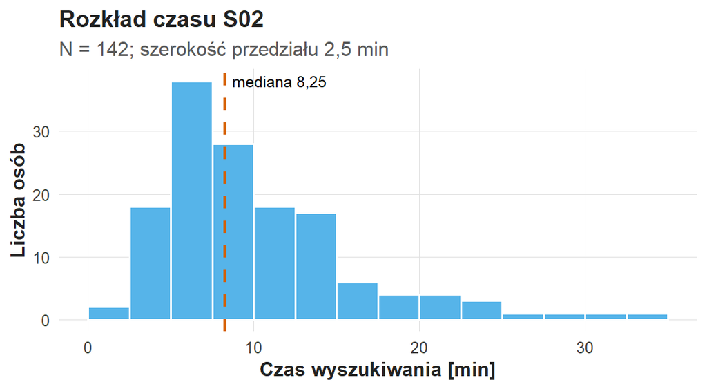

Rozkład czasu S02: histogram 142 ważnych czasów z przedziałami po 2,5 minuty. Oś pozioma: czas wyszukiwania w minutach; oś pionowa: liczba osób. Najwyższy słupek, 38 osób, stoi nad przedziałem od 5 do 7,5 minuty; linia przerywana mediany leży przy 8,25 minuty; słupki obniżają się w prawo aż do 33,8 minuty.

```r
rozklad <- pokaz_wykres(wykres_glowny)
print(rozklad)
```

Opis wykresu obejmuje zakres, skupienie, ogon i przerwy: czasy leżą od 1,6 do 33,8 minuty, 66 osób ma czas od 5 do 10 minut, a 11 osób — ponad 20 minut, co tworzy długi prawy ogon. Przyczyny długich czasów wymagają danych o interfejsie, zadaniu, urządzeniu i doświadczeniu.

Przy rozkładzie skośnym mediana i IQR uzupełniają średnią i SD; wybór podsumowania wynika z pytania, a wybór późniejszego testu — także z projektu i liczebności.

## Percentyl 90. w małej próbie

Tabela „Kwartyle, IQR i percentyl 90. [min]” zestawia obie serie: A — Q1 4, mediana 6, Q3 8, IQR 4, P90 9,2; B — Q1 4, mediana 6, Q3 8, IQR 4, P90 21,2 minuty. P90 i IQR mają jednostkę minut i odpowiadają na dwa pytania: o czas, w którym kończy się 90% prób, i o szerokość środkowej połowy.

```r
kwantyle <- kwantyle_serii()
print(kwantyle)
```

**Kwartyle, IQR i percentyl 90. [min]**

| Seria | N | Q1 | Mediana | Q3 | IQR | P90 |
| --- | --- | --- | --- | --- | --- | --- |
| A | 5 | 4 | 6 | 8 | 4 | 9,2 |
| B | 5 | 4 | 6 | 8 | 4 | 21,2 |

Wśród pięciu osób możliwe udziały to 20%, 40%, 60%, 80% i 100%; P90 = 21,2 minuty leży między czwartą wartością (8 minut) a piątą (30 minut). Przy małym N percentyl zależy od interpolacji, więc raport podaje go jako opis próby.

**Wzorzec zapisu kwartyli (APA).**

> Mediana czasu wyszukiwania wyniosła *Mdn* = 8,25 min, a rozstęp międzykwartylowy *IQR* = 7,175 min (*Q*<sub>1</sub> = 5,800 min, *Q*<sub>3</sub> = 12,975 min); mediana leży bliżej pierwszego kwartyla, co wskazuje na dłuższy prawy ogon rozkładu.

# LEARN 4: dystrybuanta podaje udział prób do danego czasu

$$\widehat F(c)=\frac{\#\{i:x_i\leq c\}}{n}.$$

Wzór brzmi słownie: „liczba ważnych czasów mniejszych lub równych progowi $c$, podzielona przez liczbę ważnych czasów”. Symbol $\#$ oznacza liczbę elementów spełniających warunek. Funkcja rośnie od 0 do 1 schodkami po jednej obserwacji.

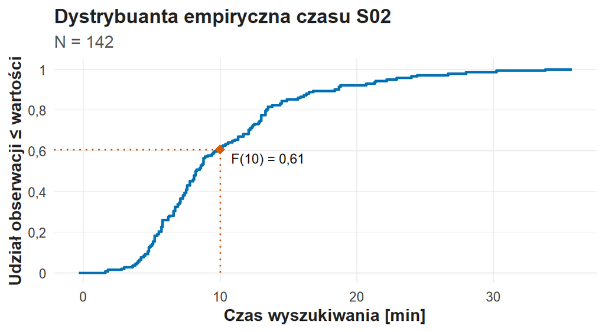

Dystrybuanta empiryczna czasu S02 (N = 142). Oś pozioma: czas wyszukiwania w minutach; oś pionowa: udział czasów mniejszych lub równych wartości. Schodki rosną najszybciej między 4 a 15 minutami; romb przy 10 minutach oznacza F(10) = 0,61, czyli 86 ze 142 czasów.

```r
dystrybuanta <- pokaz_wykres(wykres_ecdf)
print(dystrybuanta)
```

Wysokość dystrybuanty przy 10 minutach wynosi 0,606 (86 ze 142 czasów) i dotyczy samego czasu. Schodki odpowiadają pojedynczym pomiarom; przy powtarzających się czasach skok obejmuje kilka osób. Wykres „Dystrybuanty czasu w dwóch grupach” zestawia grupy na wspólnych osiach.

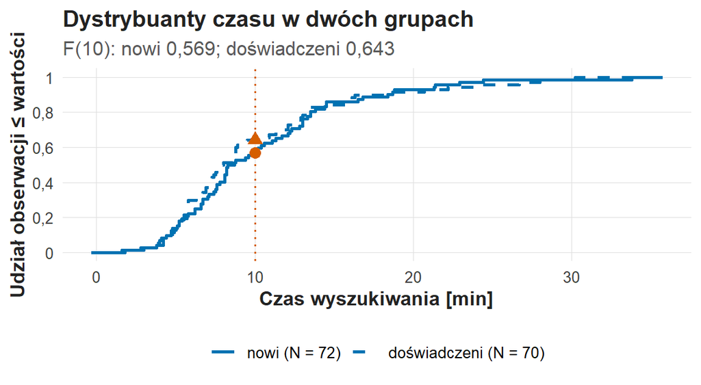

Dystrybuanty czasu w dwóch grupach. Oś pozioma: czas wyszukiwania w minutach; oś pionowa: udział czasów mniejszych lub równych wartości. Linia ciągła: nowi (N = 72), linia przerywana: doświadczeni (N = 70). Przy progu 10 minut (linia kropkowana) dystrybuanta doświadczonych wynosi 0,643, a nowych 0,569; powyżej 15 minut obie krzywe leżą blisko siebie.

```r
dystrybuanty_grup <- pokaz_wykres(wykres_ecdf_grup)
print(dystrybuanty_grup)
```

Do progu 10 minut kończy wyszukiwanie 64,3% doświadczonych i 56,9% nowych. Tabela „Dwa pytania o czas nie większy niż próg” zestawia dwa pytania o próg: pierwsze dotyczy samego czasu, drugie wymaga też powodzenia. Liczba kompletnych par czasu i powodzenia wynosi 142.

```r
prog <- opis_progow(dane, prog_min = 10)
print(prog)
```

**Dwa pytania o czas nie większy niż próg**

| Warunek | Próg [min] | Licznik | Mianownik | Procent |
| --- | --- | --- | --- | --- |
| Sam czas | 10 | 86 | 142 | 60,56 |
| Sukces i czas | 10 | 55 | 142 | 38,73 |

Osoba, która zakończyła zadanie szybko i błędnie, wchodzi do licznika pierwszego pytania i poza licznik drugiego. Dwa odsetki mają różne definicje licznika. Rekomendacja dla biblioteki wskazuje priorytet: szybkość, skuteczność albo ich połączenie.

## Powodzenie ma własny mianownik

Czas jest zmienną ilościową, a powodzenie — kategorią 0/1. Opis powodzenia podaje liczbę znanych wyników, liczbę jedynek i ich udział. N powodzenia (148) i N czasu (142) różnią się o sześć braków czasu.

Tabela „Powodzenie w każdej grupie” liczy odsetki osobno w grupach: doświadczeni — 52 sukcesy na 74 znane wyniki (70,3%), nowi — 45 na 74 (60,8%).

```r
sukcesy <- tabela_powodzen()
print(sukcesy)
```

**Powodzenie w każdej grupie**

| Grupa | Znane wyniki | Sukcesy | Sukcesy [%] |
| --- | --- | --- | --- |
| doświadczeni | 74 | 52 | 70,3 |
| nowi | 74 | 45 | 60,8 |

Duża liczba powodzeń wynika czasem z dużej liczby osób. Porównanie skuteczności wymaga udziału w grupie, a planowanie liczby obsłużonych zadań — także liczby bezwzględnej.

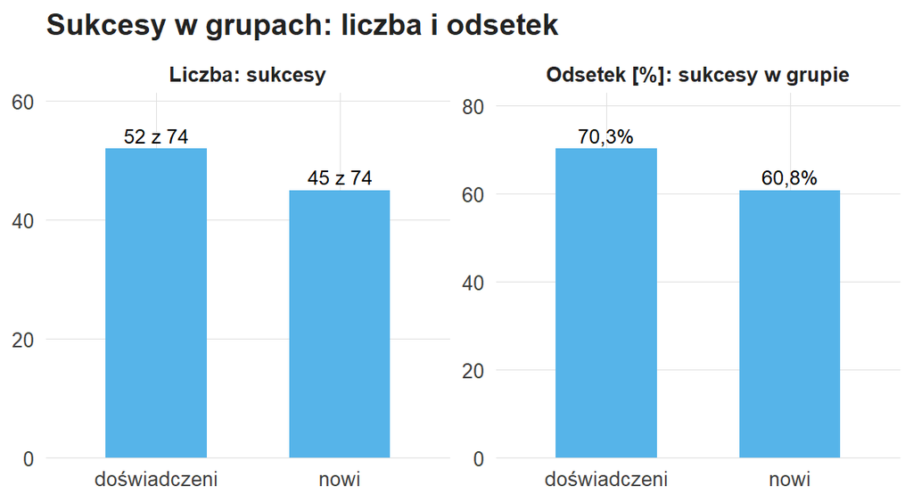

Sukcesy w grupach: liczba i odsetek. Lewy panel: liczba sukcesów — 52 z 74 doświadczonych i 45 z 74 nowych. Prawy panel: odsetek sukcesów w grupie — 70,3% doświadczonych i 60,8% nowych.

```r
skutecznosc <- pokaz_wykres(wykres_powodzen)
print(skutecznosc)
```

Różnica odsetków wynosi $70{,}3-60{,}8=9{,}5$ punktu procentowego; względnie odsetek nowych stanowi $60{,}8/70{,}3=0{,}865$ odsetka doświadczonych. Istotność różnicy odsetków sprawdza test w ćwiczeniu C07 (Kategorie i zachowanie).

**Wzorzec zapisu odsetków z progiem (APA).**

> Czas wyszukiwania wyniósł najwyżej 10 min w 86 ze 142 ważnych pomiarów (60,6%), a sukces w najwyżej 10 min osiągnięto w 55 ze 142 kompletnych par czasu i wyniku (38,7%). Pierwszy wskaźnik obejmuje także szybkie niepowodzenia, a drugi łączy poprawność z szybkością.

# LEARN 5: dwie grupy na jednym wykresie

W S02 grupy tworzą nowi i doświadczeni użytkownicy. Doświadczenie jest cechą istniejącą przed badaniem, więc różnice między grupami są obserwacyjne. Porównanie obejmuje położenie, rozrzut i obecność długich prób.

Tabela „Opis czasu w grupach [min]” podaje: doświadczeni — N = 70, średnia 9,97, mediana 7,9, SD 6,02, Q1 5,8, Q3 12,475, IQR 6,675; nowi — N = 72, średnia 10,28, mediana 8,5, SD 5,72, Q1 6,5, Q3 13, IQR 6,5 minuty.

```r
grupy <- opis_czasu_grup()
print(grupy)
```

**Opis czasu w grupach [min]**

| Grupa | N | Średnia | Mediana | SD | Q1 | Q3 | IQR |
| --- | --- | --- | --- | --- | --- | --- | --- |
| doświadczeni | 70 | 9,971 | 7,9 | 6,024 | 5,8 | 12,475 | 6,675 |
| nowi | 72 | 10,281 | 8,5 | 5,723 | 6,5 | 13,000 | 6,500 |

Rozkłady grup nakładają się, więc przynależność do grupy przewiduje czas osoby z dużym błędem. Duże zróżnicowanie wewnątrz grup ma znaczenie dla planowania wsparcia.

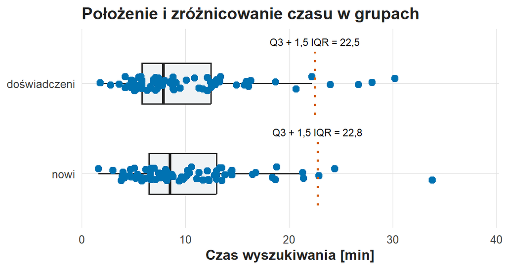

Położenie i zróżnicowanie czasu w grupach. Oś pozioma: czas wyszukiwania w minutach; dwa wiersze: doświadczeni i nowi, z punktami wszystkich osób. Doświadczeni: pudełko od 5,8 do 12,5 minuty, mediana 7,9, wąs do 22,2 minuty, kropkowana granica Q3 + 1,5 IQR przy 22,5 minuty i 4 punkty poza nią, najdłuższy 30,2 minuty. Nowi: pudełko od 6,5 do 13,0 minuty, mediana 8,5, wąs do 21,4 minuty, granica przy 22,8 minuty i 3 punkty poza nią, najdłuższy 33,8 minuty.

```r
pudelka <- pokaz_wykres(wykres_grup)
print(pudelka)
```

Granice wyznaczania wąsów wynoszą $Q_1-1{,}5\,IQR$ i $Q_3+1{,}5\,IQR$; wąs kończy się na najdalszej obserwacji w granicach. Punkty poza wąsami pozostają w danych i obliczeniach: 4 osoby doświadczone mają czas powyżej 22,5 minuty, a 3 osoby nowe — powyżej 22,8 minuty.

Pudełko streszcza pięć liczb; liczbę skupień i kształt ogona przedstawia histogram. Histogram i pudełko to dwa widoki tych samych danych. Wykres opisuje grupy; mechanizm różnicy wymaga projektu badania.

## Czas wszystkich prób i czas udanych prób

Pytanie o czas osób, którym udało się znaleźć dokument, ma mianownik 94 osób z sukcesem i ważnym czasem. Tabela „Wszystkie i udane próby; czas w minutach” podaje: wszystkie ważne czasy — N = 142, średnia 10,13, mediana 8,25, SD 5,85; udane próby — N = 94, średnia 10,19, mediana 8,70, SD 5,91 minuty.

```r
zakres <- czas_wszystkich_i_udanych()
print(zakres)
```

**Wszystkie i udane próby; czas w minutach**

| Zakres | N | Średnia | Mediana | SD |
| --- | --- | --- | --- | --- |
| Wszystkie ważne czasy | 142 | 10,13 | 8,25 | 5,85 |
| Wyłącznie udane próby | 94 | 10,19 | 8,70 | 5,91 |

Selekcja do udanych prób zmienia skład grupy. Gdy nowa pomoc umożliwia sukces także osobom potrzebującym dużo czasu, średni czas udanych prób rośnie przy poprawie skuteczności; wzrost średniej wynika wtedy ze zmiany składu grupy udanych.

Zbiór S02 pochodzi z badania obserwacyjnego, więc przykład jest scenariuszem do rozumowania. W S02 średnia udanych prób (10,19 minuty) jest bliska średniej wszystkich prób (10,13 minuty). Raport odróżnia wynik obliczony z danych od hipotetycznego wyjaśnienia mechanizmu.

## Jak napisać kompletny opis

Opis zawiera N i braki, miarę położenia, miarę rozrzutu oraz odniesienie do wykresu. Dla czasu podaje średnią i medianę, a dla powodzenia — liczbę jedynek i mianownik.

Schemat zdania wymaga uzupełnienia liczbami i obserwacjami z własnych wyników: „Wśród [N] ważnych pomiarów czasu średnia wyniosła [M] min, a mediana [Me] min. Zróżnicowanie opisują SD = [s] min i IQR = [IQR] min. Histogram wskazuje [zaobserwowana cecha]. Wyniki dotyczą [zakres próby i zadania]”.

Po zapisaniu sprawdź każdą liczbę w tabeli. Opis zawiera cechy obecne na histogramie; podobne średnią i medianę opisuje się jako podobne.

Pięć zdań do korekty

| Zdanie wymagające korekty | Źródło problemu | Poprawka |
| --- | --- | --- |
| „Typowy czas to średnia” | Typowość ma kilka znaczeń | Nazwać miarę i pytanie |
| „IQR jest przedziałem 95%” | Myli rozrzut z niepewnością | Podać kwartyle i ich rolę |
| „Grupa ma wyższy słupek, więc jest skuteczniejsza” | Porównuje same liczniki | Podać odsetki i mianowniki |
| „Punkt poza wąsem jest błędem” | Konwencja wykresu rozstrzyga o rysunku | Sprawdzić protokół i zakres |
| „Doświadczenie skróciło czas” | Grupy są obserwacyjne | Opisać związek bez przypisania przyczyny |

**Wzorzec zapisu opisu dwóch grup (APA).**

> Doświadczeni użytkownicy (*n* = 70 ważnych czasów) szukali średnio *M* = 9,97 min (*Mdn* = 7,90 min, *SD* = 6,02 min), a nowi (*n* = 72) *M* = 10,28 min (*Mdn* = 8,50 min, *SD* = 5,72 min); średnie różnią się o 0,31 min przy dużym zróżnicowaniu wewnątrz obu grup. Wskazany dokument znalazło 52 z 74 doświadczonych (70,3%) i 45 z 74 nowych (60,8%). Opis dotyczy próby; test różnicy przedstawia ćwiczenie C06 (Dwie grupy).

# CHALLENGE — samodzielny portret repozytorium

Dwanaście hipotetycznych osób (r01–r12) szuka wskazanej publikacji w repozytorium uczelni. Obserwator zapisuje czas w minutach i powodzenie 0/1. Osoba r12 ma nieznany czas i znany wynik zadania; protokół potwierdza czas 24 minut osoby r11 jako pomiar bez przerwy technicznej. Dane repozytorium są odrębne od S02 i serii A/B: z LEARN przenosisz sposób odczytu i zapisu, a liczby odczytujesz z tabel repozytorium.

Każde z pięciu zadań ma ten sam układ:

1. **Zadanie** — jedno zdanie z przedmiotem opisu.
2. **Blok R** — uruchom go; wynik zawiera wszystkie liczby potrzebne do odpowiedzi.
3. **Wskazówki** — gdzie w wyniku szukać informacji, jak ją nazwać i wzór zdania do uzupełnienia.
4. **W akapicie wymagane** — elementy, które sprawdza prowadzący.
5. **Twój akapit** — pole odpowiedzi w ramce: znacznik w nawiasie kwadratowym zastępujesz własnym tekstem, a linie komentarza nad nim i pod nim pozostawiasz bez zmian.

Akapit liczy 3–5 zdań zwykłego tekstu, bez kodu R. Liczby przepisujesz z wyniku bloku, z jednostką i mianownikiem.

## CHALLENGE 1: Raport o czasie w repozytorium

**Zadanie:** opisz czas wyszukiwania w repozytorium średnią, medianą i SD oraz wyjaśnij rozbieżność średniej i mediany.

```r
opis_repozytorium <- portret_repozytorium()
print(opis_repozytorium)
```

**Dwanaście osób w repozytorium**

| Osoba | Czas [min] | Powodzenie (0/1) |
| --- | --- | --- |
| r01 | 2 | 0 |
| r02 | 3 | 1 |
| r03 | 4 | 1 |
| r04 | 5 | 1 |
| r05 | 6 | 0 |
| r06 | 7 | 1 |
| r07 | 8 | 1 |
| r08 | 9 | 1 |
| r09 | 10 | 1 |
| r10 | 12 | 0 |
| r11 | 24 | 1 |
| r12 | NA | 1 |

**Opis ważnych czasów [min]**

| Miara | Wartość |
| --- | --- |
| N (ważne czasy) | 11,000 |
| Braki czasu | 1,000 |
| Średnia | 8,182 |
| Mediana | 7,000 |
| SD | 6,063 |
| Q1 | 4,500 |
| Q3 | 9,500 |
| IQR | 5,000 |
| P90 | 12,000 |

Blok wyświetla tabelę „Dwanaście osób w repozytorium” (osoba, czas, powodzenie 0/1) i tabelę „Opis ważnych czasów [min]” z N, brakami, średnią, medianą, SD, kwartylami, IQR i P90.

*Wskazówki:*

- N osób to liczba wierszy pierwszej tabeli; N ważnych czasów podaje pierwszy wiersz drugiej tabeli.
- Średnia odpowiada na pytanie o przeciętny nakład czasu i uwzględnia każdą próbę, także 24 minuty; mediana opisuje środek uporządkowanych czasów.
- Średnia wyższa od mediany wskazuje na długie próby po prawej stronie rozkładu.
- Brakujący czas r12 pozostaje brakiem; wynik zadania r12 wchodzi do opisu powodzenia.
- Wzorzec APA: „Spośród [N] osób czas zarejestrowano u [n] (1 brak). Średni czas wyszukiwania wyniósł *M* = [..] min (*SD* = [..] min), a mediana *Mdn* = [..] min; średnia jest wyższa od mediany, ponieważ [..]”.

*W akapicie wymagane:* (i) N osób i N ważnych czasów; (ii) średnia, mediana i SD z jednostką; (iii) pytanie, na które odpowiada średnia, i pytanie, na które odpowiada mediana; (iv) źródło rozbieżności obu miar.

**Twój akapit S01.** Znacznik w nawiasie kwadratowym zastąp własnym tekstem.

[UZUPELNIJ_S01]

## CHALLENGE 2: Obietnica „90% użytkowników”

Opiekun repozytorium chce napisać w poradniku: „90% przyszłych studentów na pewno zmieści się w P90”.

**Zadanie:** opisz kwartyle, IQR i P90 próby oraz zastąp zdanie z poradnika opisem dopuszczalnym dla jedenastu czasów.

```r
kwantyle_repozytorium <- kwantyle_i_dystrybuanta()
print(kwantyle_repozytorium)
```

**Kwantyle czasu [min]**

| Miara | Minuty |
| --- | --- |
| Q1 | 4,5 |
| Mediana | 7,0 |
| Q3 | 9,5 |
| P90 | 12,0 |
| IQR = Q3 − Q1 | 5,0 |

**Dystrybuanta przy 10 minutach**

| Ważne czasy | Czasy do 10 min | Udział [%] |
| --- | --- | --- |
| 11 | 9 | 81,82 |

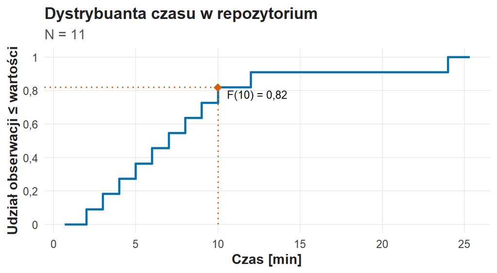

Dystrybuanta czasu w repozytorium (N = 11). Oś pozioma: czas w minutach od 2 do 24; oś pionowa: udział czasów mniejszych lub równych wartości. Schodki rosną o 1/11 przy każdym czasie; romb przy 10 minutach podaje wartość dystrybuanty; ostatni schodek, przy 24 minutach, osiąga 1.

Blok wyświetla tabelę „Kwantyle czasu [min]” (Q1, mediana, Q3, P90 i IQR), tabelę „Dystrybuanta przy 10 minutach” (liczba ważnych czasów, liczba czasów do 10 minut i ich udział) oraz wykres dystrybuanty.

*Wskazówki:*

- Q1, mediana i Q3 dzielą uporządkowane czasy na ćwiartki; IQR = Q3 − Q1 opisuje rozrzut środkowej połowy prób.
- P90 obliczono z 11 czasów przez interpolację według przyjętej konwencji; opisuje on próbę.
- Obietnica o przyszłych studentach dotyczy populacji i wymaga wnioskowania z losowej próby; zdanie o próbie podaje udział prób do danego czasu.
- Wzorzec APA: „Mediana czasu wyniosła *Mdn* = [..] min (*Q*<sub>1</sub> = [..] min, *Q*<sub>3</sub> = [..] min, *IQR* = [..] min). W próbie [n] osób [..] czasów ([..]%) wyniosło najwyżej 10 min, a percentyl 90. wyniósł [..] min”.

*W akapicie wymagane:* (i) Q1, Q3 i IQR z jednostkami; (ii) P90 z jednostką i informacją o liczbie czasów; (iii) udział prób do 10 minut; (iv) poprawione zdanie o próbie w miejsce obietnicy o przyszłych studentach.

**Twój akapit S02.** Znacznik w nawiasie kwadratowym zastąp własnym tekstem.

[UZUPELNIJ_S02]

## CHALLENGE 3: Długi czas i średnia

Osoba redagująca raport proponuje wykluczyć 24 minuty, aby średnia była niższa. Protokół potwierdza ten pomiar bez przerwy technicznej.

**Zadanie:** porównaj opis czasu z potwierdzonym pomiarem 24 minut i bez niego oraz wskaż wersję podstawową raportu.

```r
warianty <- wrazliwosc_repozytorium()
print(warianty)
```

**Wrażliwość opisu czasu [min]**

| Wariant | N | Średnia | Mediana | SD |
| --- | --- | --- | --- | --- |
| Z prawidłowym czasem 24 min | 11 | 8,182 | 7,0 | 6,063 |
| Bez czasu 24 min | 10 | 6,600 | 6,5 | 3,204 |

Blok wyświetla tabelę „Wrażliwość opisu czasu [min]” z dwoma wariantami — z prawidłowym czasem 24 minut i bez niego — oraz N, średnią, medianą i SD każdego wariantu. Czas r12 pozostaje brakiem w obu wariantach.

*Wskazówki:*

- Porównaj zmianę średniej, mediany i SD: miara zależna od każdej wartości zmienia się silniej niż miara zależna od kolejności.
- Wykluczenie potwierdzonego pomiaru zmienia opisywany zbiór osób, a wersja podstawowa raportu obejmuje wszystkie ważne pomiary.
- Wariant bez 24 minut może towarzyszyć wersji podstawowej jako jawna analiza wrażliwości z uzasadnieniem.
- Wzorzec APA: „Jedenaście ważnych czasów dało *M* = [..] min (*Mdn* = [..] min, *SD* = [..] min). Po wyłączeniu potwierdzonego pomiaru 24 min średnia wyniosłaby *M* = [..] min (*n* = [..]); pomiar pozostaje w wersji podstawowej, ponieważ [..]”.

*W akapicie wymagane:* (i) N, średnia, mediana i SD obu wariantów; (ii) która miara zmienia się najsilniej i dlaczego; (iii) ocena propozycji wykluczenia z odwołaniem do protokołu; (iv) wersja podstawowa raportu.

**Twój akapit S03.** Znacznik w nawiasie kwadratowym zastąp własnym tekstem.

[UZUPELNIJ_S03]

## CHALLENGE 4: Trzy odsetki, trzy pytania

Łączny sukces, krótki czas i sukces w krótkim czasie to trzy różne wskaźniki działania usługi; ostatni wymaga pary obserwacji tej samej osoby.

**Zadanie:** odczytaj trzy odsetki z licznikami i mianownikami i wskaż miarę celu „poprawna publikacja w najwyżej 10 minut”.

```r
trzy_wskazniki <- skutecznosc_repozytorium(prog_min = 10)
print(trzy_wskazniki)
```

**Powodzenie niezależnie od czasu**

| Sukcesy | N | Procent |
| --- | --- | --- |
| 9 | 12 | 75 |

**Warunki czasu i powodzenia**

| Warunek | Próg [min] | Licznik | Mianownik | Procent |
| --- | --- | --- | --- | --- |
| Sam czas | 10 | 9 | 11 | 81,82 |
| Sukces i czas | 10 | 7 | 11 | 63,64 |

Blok wyświetla tabelę „Powodzenie niezależnie od czasu” (sukcesy, N, procent) i tabelę „Warunki czasu i powodzenia” z progiem, licznikiem, mianownikiem i procentem dwóch warunków: samego czasu i sukcesu w czasie.

*Wskazówki:*

- Każdy odsetek ma własny mianownik: powodzenie liczy wszystkie osoby ze znanym wynikiem, a warunki z czasem — osoby z ważnym czasem.
- Warunek „sam czas” obejmuje także szybkie niepowodzenia; warunek „sukces i czas” wymaga obu warunków u tej samej osoby.
- Odsetek podajesz z ułamkiem: „[licznik] z [mianownik] ([procent]%)”.
- Wzorzec APA: „Wskazaną publikację znalazło [..] z [..] osób ([..]%). Czas wyniósł najwyżej 10 min w [..] z [..] ważnych pomiarów ([..]%), a sukces w najwyżej 10 min osiągnęło [..] z [..] osób z ważnym czasem ([..]%)”.

*W akapicie wymagane:* (i) trzy odsetki z licznikami i mianownikami; (ii) zbiór odniesienia każdego odsetka; (iii) wyjaśnienie rozbieżności; (iv) miara odpowiadająca celowi łączącemu poprawność i szybkość.

**Twój akapit S04.** Znacznik w nawiasie kwadratowym zastąp własnym tekstem.

[UZUPELNIJ_S04]

## CHALLENGE 5: Akapit dla instytucji

Instytucja rozważa zmianę instrukcji wyszukiwania. Opis obecnej próby wskazuje problemy do zbadania, a skutek zmiany instrukcji wymaga eksperymentu.

**Zadanie:** napisz akapit opisu próby dla instytucji: czas, zróżnicowanie, skuteczność, ograniczenie i następny pomiar.

```r
czas_i_sukces <- wniosek_repozytorium(prog_min = 10)
print(czas_i_sukces)
```

**Miary czasu do akapitu**

| Miara | Wartość |
| --- | --- |
| Osoby | 12,00 |
| Ważne czasy | 11,00 |
| Średnia [min] | 8,18 |
| Mediana [min] | 7,00 |
| SD [min] | 6,06 |
| IQR [min] | 5,00 |
| P90 [min] | 12,00 |

**Skuteczność do akapitu**

| Wskaźnik | Licznik | Mianownik | Procent [%] |
| --- | --- | --- | --- |
| Sukces (wszystkie osoby) | 9 | 12 | 75,00 |
| Sukces w najwyżej 10 min | 7 | 11 | 63,64 |

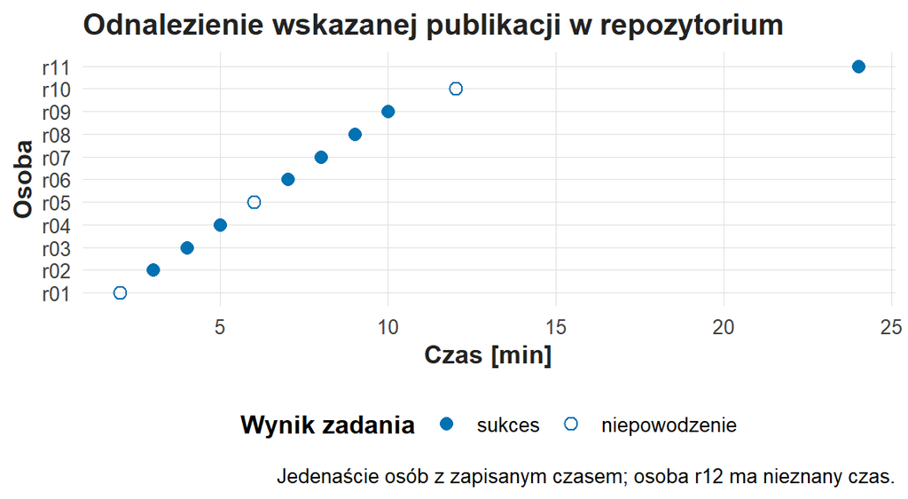

Odnalezienie wskazanej publikacji w repozytorium. Oś pozioma: czas w minutach; oś pionowa: jedenaście osób z zapisanym czasem. Koła puste (niepowodzenie) mają osoby r01 (2 minuty), r05 (6 minut) i r10 (12 minut); pozostałe osoby mają koła pełne (sukces), w tym r11 przy 24 minutach.

Blok wyświetla tabelę „Miary czasu do akapitu” (osoby, ważne czasy, średnia, mediana, SD, IQR, P90), tabelę „Skuteczność do akapitu” (sukces wszystkich osób i sukces w najwyżej 10 minut z licznikiem, mianownikiem i procentem) oraz wykres czasu i wyniku każdej osoby.

*Wskazówki:*

- Kolejność akapitu: liczebność, położenie, rozrzut, skuteczność, obserwacja z wykresu, ograniczenie, następny pomiar.
- Z wykresu odczytaj, przy jakich czasach wystąpiły niepowodzenia: krótkie próby mogą oznaczać szybką rezygnację.
- Ograniczenie: jedenaście czasów z jednego zadania w próbie syntetycznej; opis dotyczy próby.
- Następny pomiar dotyczy mechanizmu: np. zapis przyczyny zakończenia próby albo porównanie dwóch instrukcji z losowym przydziałem.
- Wzorzec APA: „W repozytorium [n] z [N] osób miało zarejestrowany czas (*M* = [..] min, *Mdn* = [..] min, *SD* = [..] min, *IQR* = [..] min). Publikację znalazło [..] z [..] osób ([..]%), a w najwyżej 10 min — [..] z [..] ([..]%). [Obserwacja z wykresu]. Opis dotyczy próby; skutek zmiany instrukcji wymaga [..]”.

*W akapicie wymagane:* (i) N i miary czasu z jednostkami; (ii) skuteczność z mianownikiem; (iii) jedna obserwacja z wykresu; (iv) ograniczenie opisu; (v) propozycja następnego pomiaru bez wniosku o przyczynie.

**Twój akapit S05.** Znacznik w nawiasie kwadratowym zastąp własnym tekstem.

[UZUPELNIJ_S05]

# Zapis i oddanie

Sprawdź pięć własnych odpowiedzi: każda liczba odnosi się do właściwego zbioru, miary i jednostki. Sprawdź nazwy miar: SD opisuje osoby, a sukces opisuje kolumna powodzenia. Zapisz plik `zadanie.Rmd` w edytorze (Ctrl+S); funkcja oddania tworzy PDF z zapisanego pliku.

W konsoli wykonaj jedno polecenie. Funkcja oddania tworzy aktualny PDF, sprawdza kompletność, otwiera PDF do obejrzenia i po potwierdzeniu literą `t` wysyła go do folderu zadania prowadzącego na serwerze UJ (nc.uj.edu.pl). Nazwa pliku zawiera Twoje ID oraz nazwisko i imię.

```r
oddaj_zadanie("Z03")
```

Oddanie potwierdza komunikat z nazwą wysłanego pliku, folderem i czasem; plik `oddania.csv` w folderze `moje-badania` zapisuje także sumę SHA-256 wysłanego PDF. Po komunikacie błędu popraw wskazany problem, zapisz plik i ponownie wywołaj `oddaj_zadanie("Z03")`; nowa wersja trafia do folderu obok poprzedniej. Ocenę prowadzący przekazuje osobno.

Po potwierdzonym oddaniu możesz zamknąć projekt: Posit Cloud zachowuje folder `moje-badania` do kolejnych zajęć. Na komputerze współdzielonym wyloguj się z Posit Cloud w przeglądarce. Przy braku sieci PDF pozostaje w folderze zadania; wyślij go tym samym poleceniem po odzyskaniu połączenia, a gdy problem trwa, poproś prowadzącego o ustalenie sposobu dostarczenia pracy.

## Co jest oceniane

| Kryterium | Dowód w Twojej pracy | Odpowiedzi | Punkty |
| --- | --- | --- | --- |
| Z03.1 N, położenie i zróżnicowanie czasu | N osób i czasów, średnia, mediana, SD, Q1, Q3, IQR i P90 z jednostkami; zmiany po wyłączeniu czasu 24 minut | S01, S02, S03 | 3 |
| Z03.2 Odczyt dystrybuanty oraz wykresu czasu i sukcesu | Dystrybuanta powiązana z odsetkiem zarejestrowanych czasów; odczyt drugiego wykresu z rozróżnieniem czasu i sukcesu | S02, S05 | 3 |
| Z03.3 Uzasadnienie doboru miar i zachowania potwierdzonego czasu | Różnica średniej i mediany przy asymetrii; zmiana miar po pominięciu 24 minut i uzasadnienie wersji podstawowej | S01, S03 | 2 |
| Z03.4 Mianowniki, synteza i granice opisu próby | Trzy odsetki z mianownikami i wybór kryterium łącznego; synteza z liczbami, ograniczeniem i dodatkowym pomiarem | S04, S05 | 2 |

Ocena dotyczy zgodności zdania z danymi. Poziomy wykonania opisuje rubryka Z03: na stronie kursu w dokumencie `rubryki/Z03.html`, a w konsoli R po poleceniu `rubryka("Z03")`.

# Rozwinięcia do powtórki — poza rdzeniem spotkania

Rozwinięcia stosują odczyt z LEARN do szerokości przedziałów, jednostek, modelu normalnego i składu próby. Rozwinięcia służą powtórce i pozostają poza oceną.

## Szerokość przedziału histogramu

Wykres „Ten sam czas przy dwóch szerokościach przedziału” przedstawia 142 czasy S02 z przedziałami po 5 minut i po 1,25 minuty.

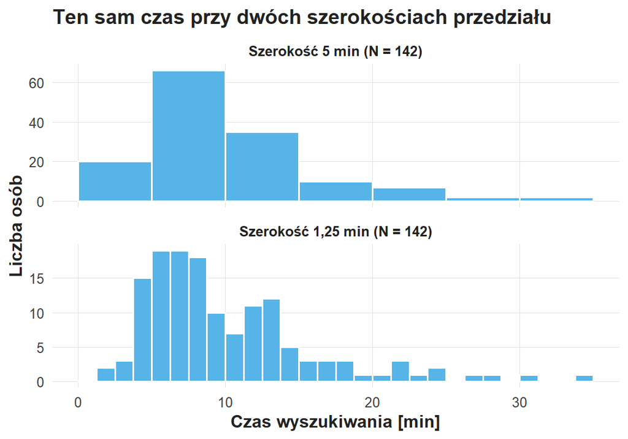

Ten sam czas przy dwóch szerokościach przedziału (N = 142 w obu panelach). Oś pozioma: czas wyszukiwania w minutach; oś pionowa: liczba osób. Przy 5 minutach histogram ma jeden szczyt nad przedziałem od 5 do 10 minut (66 osób) i gładki prawy ogon. Przy 1,25 minuty szczyt dzieli się na kilka słupków o nieregularnych wysokościach, a w prawym ogonie pojawiają się puste przedziały.

```r
histogramy <- porownanie_histogramow()
print(histogramy)
```

Szerokość przedziału zmienia wysokości słupków, a wartości czasu i N = 142 pozostają te same. Ustawienie wybiera się tak, aby kształt był stały przy sąsiednich szerokościach; histogram ma pomóc odbiorcy zrozumieć rozkład.

## Histogram gęstości i krzywa normalna

Wykres „Histogram gęstości i krzywa normalna” zestawia rozkład empiryczny czasu S02 z krzywą rozkładu normalnego o średniej 10,13 i SD 5,85 minuty.

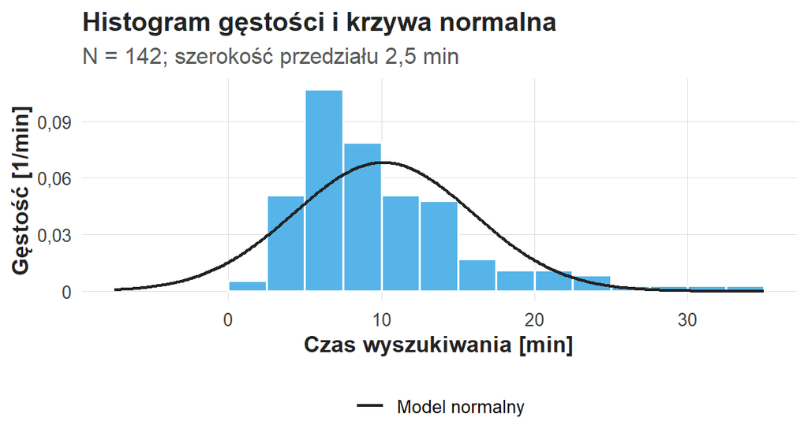

Histogram gęstości i krzywa normalna. Oś pozioma: czas wyszukiwania w minutach; oś pionowa: gęstość na minutę. Słupki histogramu mają szczyt nad przedziałem od 5 do 7,5 minuty i prawy ogon do 33,8 minuty. Krzywa normalna jest symetryczna wokół 10,13 minuty, zaczyna się poniżej zera i ma szczyt niższy od najwyższego słupka.

```r
normalny <- pokaz_wykres(wykres_normalny)
print(normalny)
```

Krzywa normalna przypisuje 4,2% pola czasom ujemnym i 4,6% czasom powyżej 20 minut; w danych czasy powyżej 20 minut stanowią 7,7%. W przedziale średnia ± SD leży 78,9% czasów, a krzywa przewiduje 68%. Model normalny opisuje więc czas S02 niedokładnie w obu ogonach.

## Jednostki i transformacje

Zamiana minut na sekundy mnoży każdą wartość przez 60: średnia, mediana, SD i IQR rosną sześćdziesięciokrotnie, a wariancja $60^2$ razy. Współczynnik zmienności i wynik standaryzowany mają postać:

$$CV=\frac{s}{\bar{x}},\qquad z_i=\frac{x_i-\bar{x}}{s}.$$

Tabela „Ten sam czas w dwóch jednostkach” podaje: średnia 10,13 minuty = 607,7 sekundy; SD 5,85 minuty = 351,3 sekundy; CV = 0,578 w obu jednostkach.

```r
jednostki <- jednostki_czasu()
print(jednostki)
```

**Ten sam czas w dwóch jednostkach**

| Jednostka | Średnia | SD | CV |
| --- | --- | --- | --- |
| minuty | 10,128 | 5,854 | 0,578 |
| sekundy | 607,690 | 351,267 | 0,578 |

CV wymaga zmiennej ze skalą ilorazową i dodatnią średnią, np. czasu; dla indeksu 1–5 z umownym początkiem skali CV zależy od umownego zera. Wynik $z=1$ oznacza czas o jedno SD dłuższy od średniej; po zmianie próby średnia i SD odniesienia się zmieniają, więc ten sam czas dostaje inne z.

Logarytm dodatniego czasu przedstawia relacje ilorazowe: podwojenie czasu odpowiada stałej różnicy logarytmów. Średnia logarytmów po przekształceniu wykładniczym daje średnią geometryczną:

$$G=\exp\!\left(\frac{1}{n}\sum_{i=1}^{n}\ln x_i\right)=\sqrt[n]{x_1\cdots x_n}:\qquad G=8{,}74 \text{ minuty w S02},$$

wobec średniej arytmetycznej 10,13 minuty. Logarytm wymaga czasu dodatniego, a dopisanie stałej do czasu zmienia analizowaną wielkość. Zadanie Z03 używa oryginalnych minut.

## Trzy dodatkowe przykłady odczytu

### Próba A: taka sama średnia, inne doświadczenie

Pierwsza mała grupa ma czasy 4, 5, 6, 7 i 8 minut, druga 0, 2, 6, 10 i 12 minut; obie średnie wynoszą 6 minut. Czy usługa działa w obu grupach tak samo?

Druga grupa jest bardziej zróżnicowana: SD 5,10 wobec 1,58 minuty. Czas 0 wymaga sprawdzenia zapisu: natychmiastowy wynik, zaokrąglenie albo błędny wpis. Opis obu grup podaje średnią, SD i pełny rozkład.

### Próba B: dwie średnie z różnych liczebności

W grupie dziesięciu osób średni czas wynosi 4 minuty, a w grupie trzydziestu — 8 minut. Średnia ogólna wynika z sum czasu: $10\cdot4+30\cdot8=280$ minut podzielone przez 40 osób daje 7 minut. Średnia dwóch średnich wynosi 6 i nadaje grupom równe wagi.

### Próba C: dwa odsetki z różnych mianowników

W małej filii sukces odnosi 8 z 10 osób, a w dużej 45 z 90. Ogólny odsetek wynosi $53/100=53\%$; średnia dwóch odsetków (65%) traktuje filie jak równoliczne. Ogólny wynik i wyniki filii odpowiadają na dwa pytania, a wniosek o przyczynie różnicy wymaga informacji o zadaniach, osobach i warunkach.

## Cztery osoby, cztery różne doświadczenia

W małej demonstracji osoba a kończy poprawnie po 2 minutach, b błędnie po 3, c poprawnie po 14, a d błędnie po 16. Przy kryterium czasu b wyprzedza c; przy kryterium znalezienia właściwego dokumentu kolejność się odwraca. Ocena wymaga definicji wyniku.

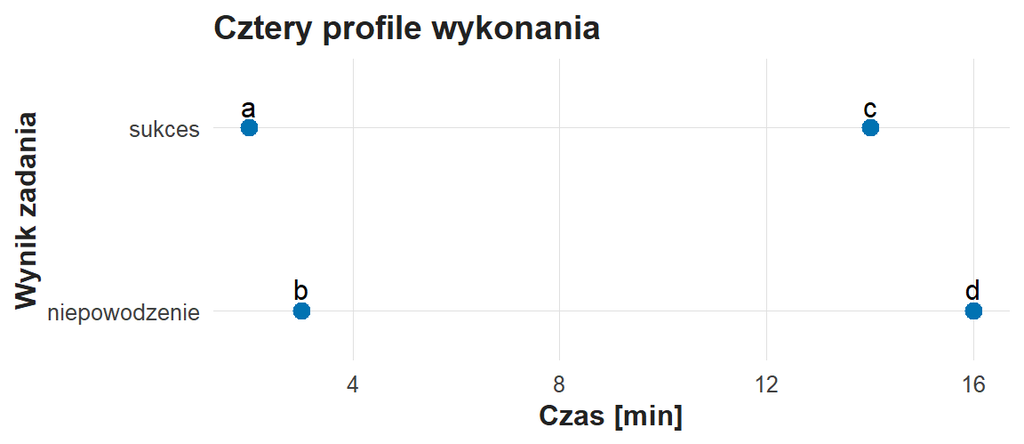

Cztery profile wykonania. Oś pozioma: czas w minutach; oś pionowa: wynik zadania. Osoby a (2 minuty) i c (14 minut) leżą na poziomie sukcesu, osoby b (3 minuty) i d (16 minut) — na poziomie niepowodzenia.

```r
profile <- pokaz_wykres(wykres_profili)
print(profile)
```

Osoba a wykonała zadanie szybko i poprawnie. Osoba b szybko zrezygnowała, źle zrozumiała instrukcję albo wskazała pierwszy znaleziony wynik — trzy wyjaśnienia wyniku b to hipotezy. Osoba c osiągnęła sukces mimo dłuższego czasu, a osoba d poświęciła dużo czasu bez sukcesu i jest szczególnie ważna dla diagnozy bariery.

Ocena kompetencji wymaga wielu zadań o znanej trudności i zdefiniowanego obszaru: odnalezienie sygnatury i ocena wiarygodności to dwa obszary. Wynik złożony z czasu i poprawności wymaga jawnych wag i reguły.

## Czas ucięty limitem obserwacji

Inny protokół kończy każdą próbę po 15 minutach; trzy osoby jeszcze szukają i otrzymują zapis 15. Zapis 15 minut oznacza czas co najmniej 15 minut: w okresie obserwacji osoby szukały dalej.

Pytanie o czas zajmowania stanowiska w sesji ograniczonej do 15 minut korzysta z zapisu wprost. Pytanie o czas skutecznego wyszukania wymaga uwzględnienia zakończenia obserwacji: analiza czasu do zdarzenia traktuje zakończenie obserwacji przed zdarzeniem jako cenzurowanie prawostronne, a zwykła średnia zapisów odpowiada na pytanie o czas trwania sesji. Protokół S02 rejestruje czas bez limitu, więc wysokie wartości są pełnymi pomiarami.

## Skład próby może odwrócić porównanie

Biblioteka porównuje dwie wersje usługi, A i B, a w każdej zarejestrowano inne zadania: w A przeważają łatwe, w B trudne. Dane dobrano wyłącznie do demonstracji. Tabela „Wyniki wewnątrz rodzaju zadania” podaje odsetki w każdym typie zadania: w łatwym obie wersje mają 90%, w trudnym A 20% (2/10), a B 30% (27/90).

```r
sklad <- sklad_zadan()
print(sklad)
```

**Wyniki wewnątrz rodzaju zadania**

| Wersja | Zadanie | Sukcesy | N | Sukces [%] |
| --- | --- | --- | --- | --- |
| A | łatwe | 81 | 90 | 90 |
| A | trudne | 2 | 10 | 20 |
| B | łatwe | 9 | 10 | 90 |
| B | trudne | 27 | 90 | 30 |

Tabela „Wyniki po połączeniu zadań” łączy typy zadań: ogółem A ma 83% (83/100), a B 36% (36/100).

```r
wynik_laczny <- sklad_polaczony()
print(wynik_laczny)
```

**Wyniki po połączeniu zadań**

| Wersja | Sukcesy | N | Sukces [%] |
| --- | --- | --- | --- |
| A | 83 | 100 | 83 |
| B | 36 | 100 | 36 |

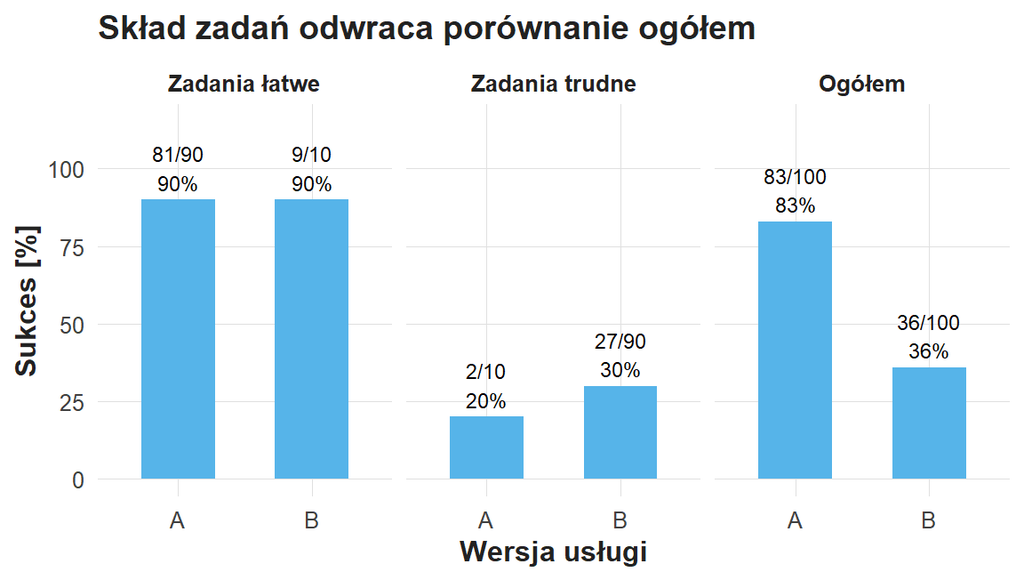

Skład zadań odwraca porównanie ogółem. Trzy panele słupków: zadania łatwe — A 81/90 (90%), B 9/10 (90%); zadania trudne — A 2/10 (20%), B 27/90 (30%); ogółem — A 83/100 (83%), B 36/100 (36%).

```r
simpson <- pokaz_wykres(wykres_simpson)
print(simpson)
```

Rachunek jest poprawny, a wynik ogółem zależy od wag: A ma 90% zadań łatwych, B — 10%. Zjawisko nosi nazwę paradoksu Simpsona. Odsetek standaryzowany używa wspólnych wag $w_k$ dla typów zadań:

$$\hat{p}_{\text{ogółem}}=\frac{\sum_k s_k}{\sum_k n_k},\qquad \hat{p}_{\text{std}}=\sum_k w_k\,\hat{p}_k ,$$

gdzie $s_k$ i $n_k$ to sukcesy i liczba osób w typie zadania $k$, a $\hat{p}_k=s_k/n_k$. Przy wagach $w_k=0{,}5$ rachunek daje:

$$A:\ 0{,}5\cdot90\%+0{,}5\cdot20\%=55\%,\qquad B:\ 0{,}5\cdot90\%+0{,}5\cdot30\%=60\%.$$

Tabela „Hipotetyczna mieszanka pół na pół” podaje oba odsetki standaryzowane.

```r
wynik_wazony <- sklad_wazony()
print(wynik_wazony)
```

**Hipotetyczna mieszanka pół na pół**

| Wersja | Sukces przy wagach 50/50 [%] |
| --- | --- |
| A | 55 |
| B | 60 |

Przy wspólnych wagach B ma 60%, a A 55%; wniosek o przyczynie wymaga porównywalnych osób i warunków. Wagi 50/50 są wyborem dydaktycznym i wymagają uzasadnienia w rzeczywistym badaniu. Podobny problem pojawia się przy łączeniu początkujących z ekspertami, prostych zapytań z problemami badawczymi albo korzystania mobilnego ze stacjonarnym; pierwszym krokiem jest tabela liczebności według typu zadania.

## Od wykresu do decyzji: trzy krótkie recenzje

**Recenzja 1.** Autor porównuje czas na dwóch histogramach liczebności: jednym dla 30 osób, drugim dla 300, i pisze, że drugi rozkład jest dziesięć razy bardziej intensywny. Porównanie kształtu wymaga wspólnej skali gęstości i tego samego podziału osi, jak na wykresie „Histogramy gęstości dwóch grup”; liczebności podaje się obok.

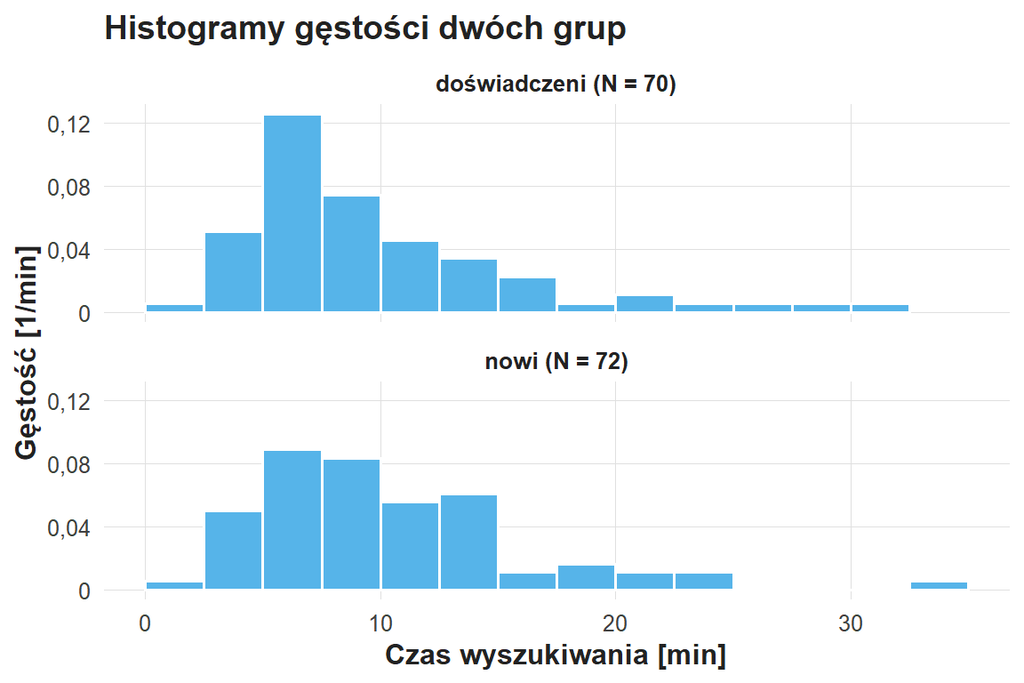

Histogramy gęstości dwóch grup S02 z przedziałami po 2,5 minuty. Oś pozioma: czas wyszukiwania w minutach; oś pionowa: gęstość na minutę, wspólna dla obu paneli. Oba panele mają szczyt między 5 a 7,5 minuty: u doświadczonych (N = 70) gęstość 0,126, czyli 22 osoby, u nowych (N = 72) gęstość 0,089, czyli 16 osób; oba mają prawy ogon, a pole słupków każdego panelu wynosi 1.

```r
gestosci_grup <- pokaz_wykres(wykres_gestosci_grup)
print(gestosci_grup)
```

**Recenzja 2.** Autor przedstawia dwa pudełka z osią czasu od 9 do 11 minut, a niewielka różnica median zajmuje większość wysokości wykresu. Zawężona oś uwidacznia szczegół; podpis podaje wielkość różnicy w minutach.

**Recenzja 3.** Raport stwierdza: „wyniki są stabilne, bo SD jest małe”. SD z przekrojowej próby opisuje podobieństwo osób; powtarzalność pomiaru wymaga powtórnych pomiarów tej samej osoby, a precyzja średniej — błędu standardowego. Poprawa polega na podaniu właściwego mianownika i właściwej miary.

## Samokontrola przed własnym opisem

Weź jedną liczbę z podsumowania S02 i odpowiedz pełnymi zdaniami: z których rekordów powstała, co wykluczono, jaka jest jednostka i na jakie pytanie odpowiada. Następnie wskaż zdanie, które wymaga innej liczby: dla mediany — twierdzenie o całkowitym koszcie czasu, dla odsetka powodzeń — twierdzenie o szybkości, a dla SD — twierdzenie o błędzie średniej.

Próba służy powtórce przed zadaniem Z03. Dobry opis pozostaje poprawny po usunięciu wykresu z raportu, a dobry wykres pozwala sprawdzić najważniejsze zdanie opisu.

Ćwiczenie C04 (Od pozycji do konstruktu: samoocena i wykonanie zadania) wraca do ankiety: opisuje, jak z pojedynczych odpowiedzi powstaje indeks i co indeks mierzy. Zasada z C03 obowiązuje dalej: najpierw definicja wielkości, potem odczyt liczby. Długi czas, wysoka ocena katalogu i prawidłowe wykonanie zadania to trzy elementy historii użytkownika.